NetCapital by NetSimR

# Portfolio Capital Report

Generated 20 November 2026, 13:55

## Key results

3 lines, 20,000 simulated years, Gaussian copula.

Mean total loss

671,257

Standard deviation 367,287

VaR 99.5%

2,264,892

Of the total

TVaR 99.5%

3,313,282

The mean beyond the VaR

Diversification benefit

682,892

23.2% of the lines' VaR

Lines' VaR

2,947,784

The sum of the lines' own VaR

## Lines and dependence

### Lines

| Line | Claim count | Claim size |
| --- | --- | --- |
| Motor | Poisson (50) | LogNormal (8, 1) |
| Property | Poisson (5) | Pareto ( 1.8, 20000.0) |
| Liability | Negative Binomial (4, 2) | LogNormal (9.0, 1.5) |

Each line simulated with simulate_claims(): its claim count and claim size distributions, with their parameters.

### Correlations of the copula

| Line | Motor | Property | Liability |
| --- | --- | --- | --- |
| Motor | 1.00 | 0.25 | 0.25 |
| Property | 0.25 | 1.00 | 0.25 |
| Liability | 0.25 | 0.25 | 1.00 |

The correlations of the copula's normal draws, which give the ranks of the lines' losses.

Simulation

**Simulations**

20,000

**Level**

99.5%

**Copula**

Gaussian

**Seed**

1

## Capital by line

| Line | Mean | Standard deviation | VaR 99.5% | TVaR 99.5% | Capital | Share |
| --- | --- | --- | --- | --- | --- | --- |
| Motor | 245,673 | 57,400 | 431,722 | 474,597 | 310,044 | 9.4% |
| Property | 223,855 | 217,936 | 1,122,307 | 1,986,134 | 1,417,911 | 42.8% |
| Liability | 201,730 | 242,369 | 1,393,755 | 2,017,439 | 1,585,327 | 47.8% |
| Total | 671,257 | 367,287 | 2,264,892 | 3,313,282 | 3,313,282 | 100.0% |

Each line's VaR and TVaR are its own. Its capital is its mean loss in the years when the total is at or beyond its VaR (co-TVaR, the Euler allocation of the TVaR), so the capitals add up to the total's TVaR.

### Capital by line

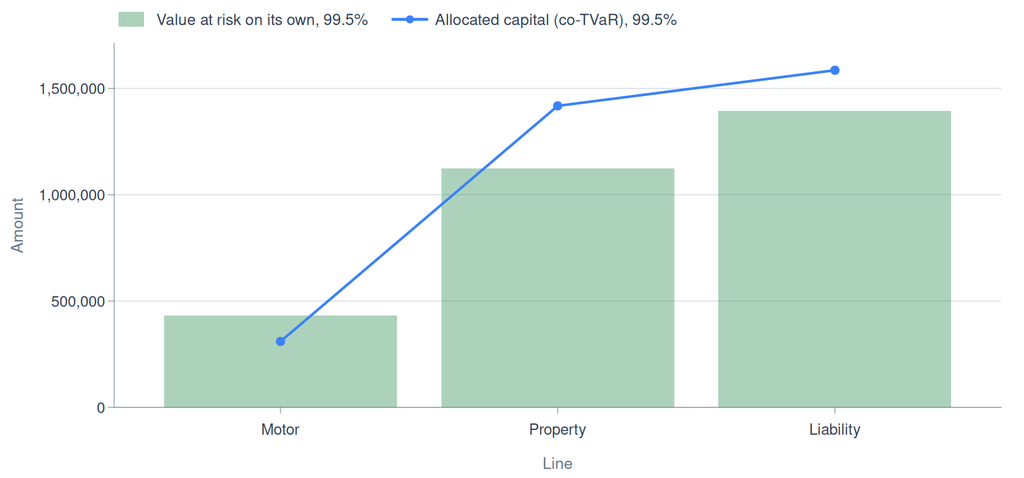

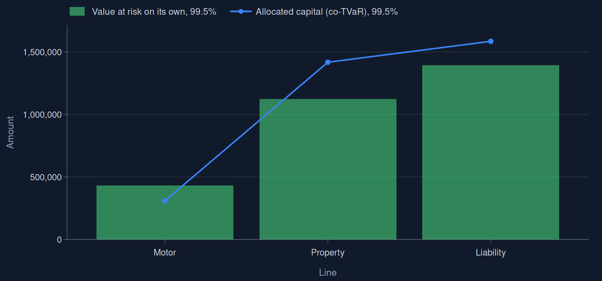

## Charts

### Total losses

Dashed lines mark the mean and the VaR, the dotted line the TVaR.

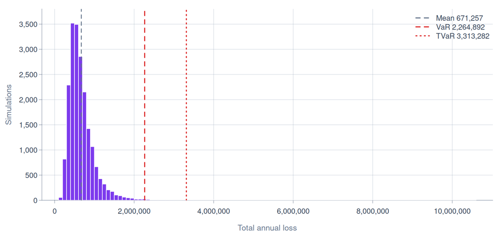

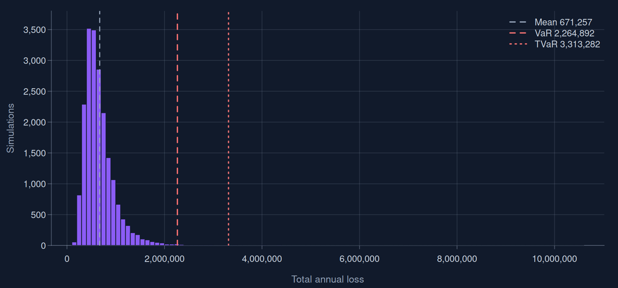

### Dependence of Motor and Property

Each point is a simulated year at the ranks of the two lines' losses; the square holds the years in the worst 5% of both.

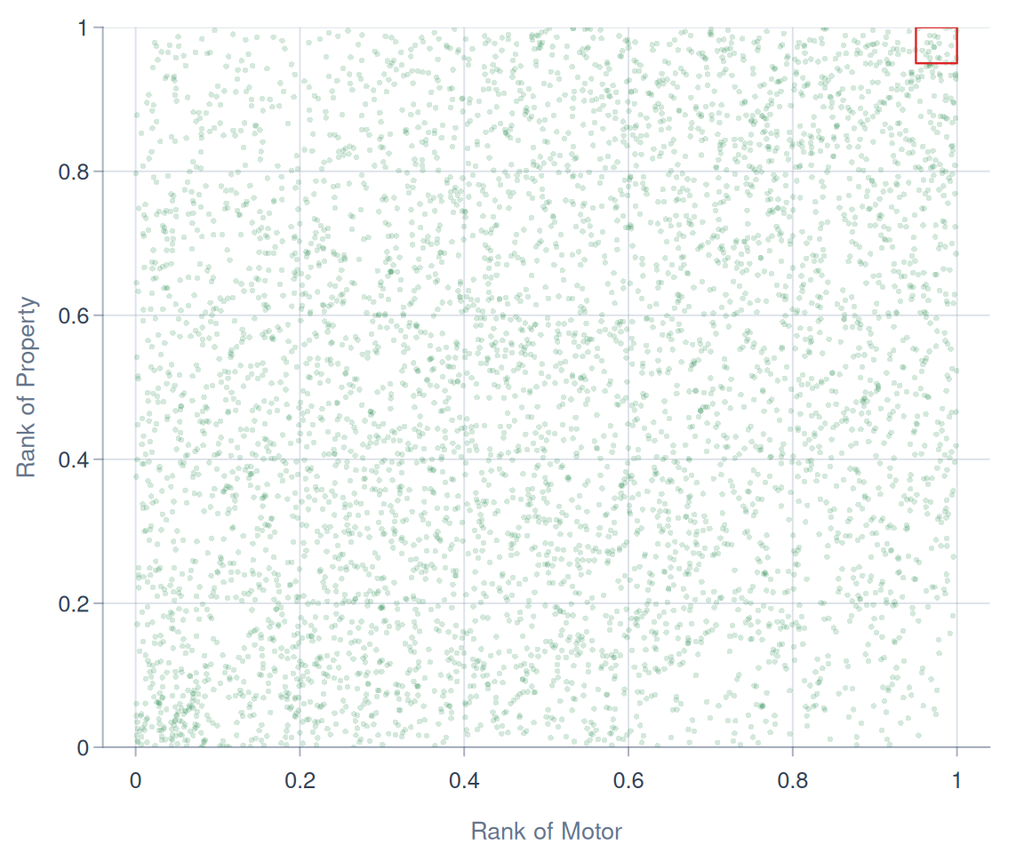

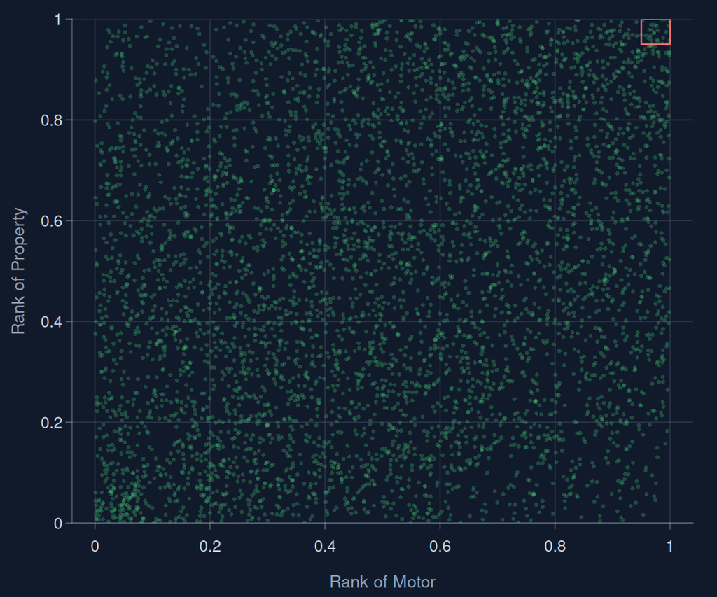

## How to read this report

- The VaR at 99.5% is the loss exceeded in 0.5% of the years; the TVaR is the mean of those years.
- The diversification benefit is how much less capital the lines need together than on their own.
- Each line keeps its own distribution: the copula only orders the lines' losses, so that their ranks have its dependence.
- The figures are those of the simulations: with more simulations, the tail figures move less from one run to another.